# Edureka_linear_Reg

Jeswin

4 October 2017

# Linear Regression Example

```r
library(ggplot2)
suppressMessages(library(dplyr))
library(tidyr)
suppressMessages(library(gridExtra))
suppressMessages(library(GGally))
library(RColorBrewer)
suppressMessages(library(scales))
suppressMessages(library(memisc))
suppressMessages(library(car))
suppressMessages(library(MASS))
suppressMessages(library(caTools))
library(lattice)
library(car)
```

### Real estate consultation firm has the data comprising price of apartments in Boston. Based on this data, company wants to decide the price of new apartments

#### Data Acquisition

```r
data(Boston)  # from MASS library
summary(Boston)
```

```
##       crim                zn             indus            chas
##  Min.   : 0.00632   Min.   :  0.00   Min.   : 0.46   Min.   :0.00000
##  1st Qu.: 0.08204   1st Qu.:  0.00   1st Qu.: 5.19   1st Qu.:0.00000
##  Median : 0.25651   Median :  0.00   Median : 9.69   Median :0.00000
##  Mean   : 3.61352   Mean   : 11.36   Mean   :11.14   Mean   :0.06917
##  3rd Qu.: 3.67708   3rd Qu.: 12.50   3rd Qu.:18.10   3rd Qu.:0.00000
##  Max.   :88.97620   Max.   :100.00   Max.   :27.74   Max.   :1.00000
##       nox               rm             age              dis
##  Min.   :0.3850   Min.   :3.561   Min.   :  2.90   Min.   : 1.130
##  1st Qu.:0.4490   1st Qu.:5.886   1st Qu.: 45.02   1st Qu.: 2.100
##  Median :0.5380   Median :6.208   Median : 77.50   Median : 3.207
##  Mean   :0.5547   Mean   :6.285   Mean   : 68.57   Mean   : 3.795
##  3rd Qu.:0.6240   3rd Qu.:6.623   3rd Qu.: 94.08   3rd Qu.: 5.188
##  Max.   :0.8710   Max.   :8.780   Max.   :100.00   Max.   :12.127
##       rad              tax           ptratio          black
##  Min.   : 1.000   Min.   :187.0   Min.   :12.60   Min.   :  0.32
##  1st Qu.: 4.000   1st Qu.:279.0   1st Qu.:17.40   1st Qu.:375.38
##  Median : 5.000   Median :330.0   Median :19.05   Median :391.44
##  Mean   : 9.549   Mean   :408.2   Mean   :18.46   Mean   :356.67
##  3rd Qu.:24.000   3rd Qu.:666.0   3rd Qu.:20.20   3rd Qu.:396.23
##  Max.   :24.000   Max.   :711.0   Max.   :22.00   Max.   :396.90
##      lstat            medv
##  Min.   : 1.73   Min.   : 5.00
##  1st Qu.: 6.95   1st Qu.:17.02
##  Median :11.36   Median :21.20
##  Mean   :12.65   Mean   :22.53
##  3rd Qu.:16.95   3rd Qu.:25.00
##  Max.   :37.97   Max.   :50.00
```

Split the dataset into training and testing dataset in the ratio 70:30.

```r
set.seed(2)
split <- sample.split(Boston$medv,SplitRatio = 0.7)

training_data <- subset(Boston, split == TRUE)
testing_data <- subset(Boston, split == FALSE)
```

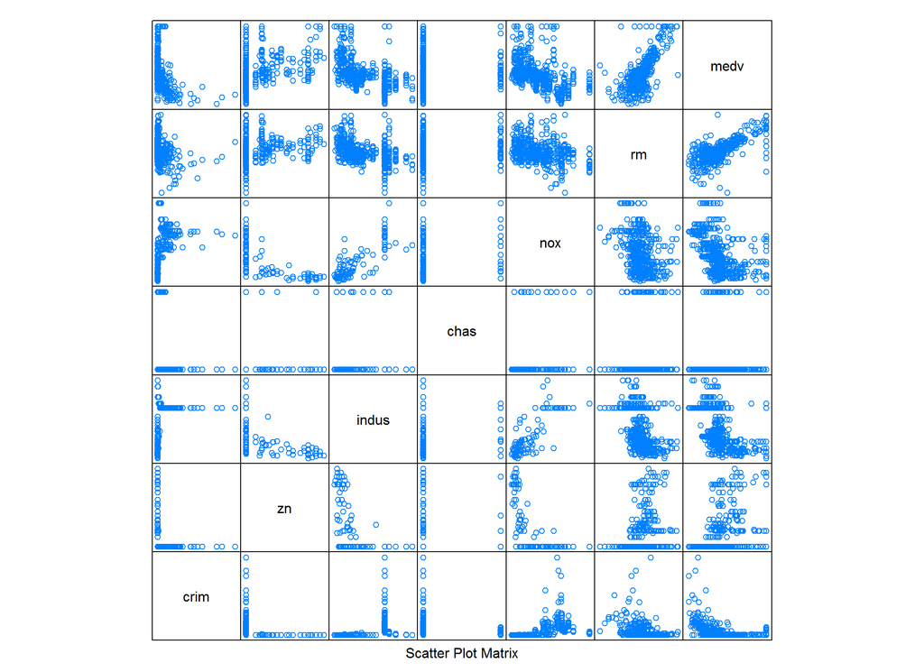

```r
# lattice library
splom(~Boston[c(1:6,14)],groups = NULL, data = Boston, axis.line.tck=0,axis.text.alpha = 0)
```

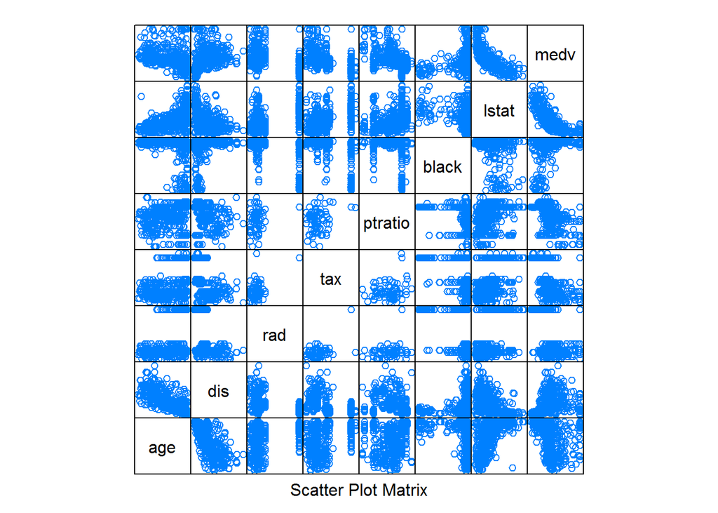

```r
splom(~Boston[c(7:14)],groups = NULL, data = Boston, axis.line.tck=0,axis.text.alpha = 0)
```

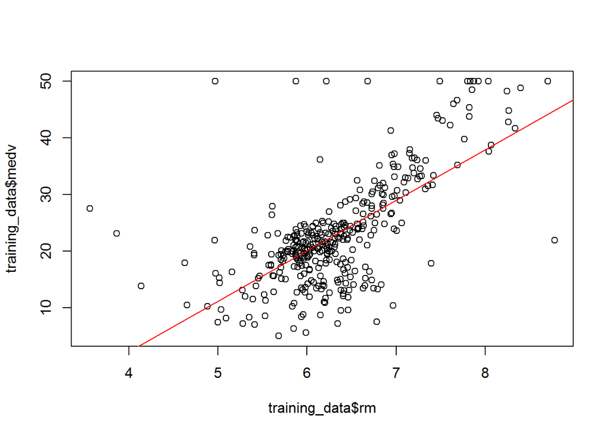

```r
# studying rm and medv
plot(training_data$rm,training_data$medv)
abline(lm(training_data$medv~training_data$rm), col='red')  # regression fit line
```

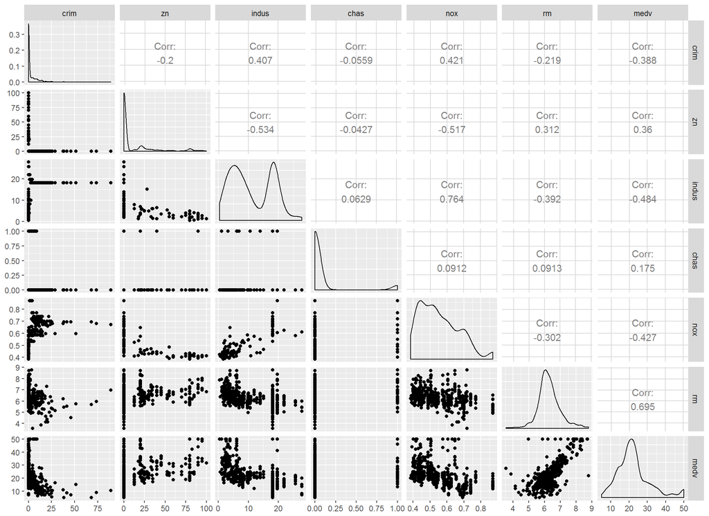

```r
Boston_df <- Boston %>%
  dplyr::select(1:6,14)   # select fn of dplyr was masked by select of MASS library
                          # To avoid such problems

ggpairs(data = Boston_df)
```

To find correlation relationship among different variables use:

```r
cr <- cor(Boston)
cr
```

```
##                crim          zn       indus         chas         nox
## crim     1.00000000 -0.20046922  0.40658341 -0.055891582  0.42097171
## zn      -0.20046922  1.00000000 -0.53382819 -0.042696719 -0.51660371
## indus    0.40658341 -0.53382819  1.00000000  0.062938027  0.76365145
## chas    -0.05589158 -0.04269672  0.06293803  1.000000000  0.09120281
## nox      0.42097171 -0.51660371  0.76365145  0.091202807  1.00000000
## rm      -0.21924670  0.31199059 -0.39167585  0.091251225 -0.30218819
## age      0.35273425 -0.56953734  0.64477851  0.086517774  0.73147010
## dis     -0.37967009  0.66440822 -0.70802699 -0.099175780 -0.76923011
## rad      0.62550515 -0.31194783  0.59512927 -0.007368241  0.61144056
## tax      0.58276431 -0.31456332  0.72076018 -0.035586518  0.66802320
## ptratio  0.28994558 -0.39167855  0.38324756 -0.121515174  0.18893268
## black   -0.38506394  0.17552032 -0.35697654  0.048788485 -0.38005064
## lstat    0.45562148 -0.41299457  0.60379972 -0.053929298  0.59087892
## medv    -0.38830461  0.36044534 -0.48372516  0.175260177 -0.42732077
##                  rm         age         dis          rad         tax
## crim    -0.21924670  0.35273425 -0.37967009  0.625505145  0.58276431
## zn       0.31199059 -0.56953734  0.66440822 -0.311947826 -0.31456332
## indus   -0.39167585  0.64477851 -0.70802699  0.595129275  0.72076018
## chas     0.09125123  0.08651777 -0.09917578 -0.007368241 -0.03558652
## nox     -0.30218819  0.73147010 -0.76923011  0.611440563  0.66802320
## rm       1.00000000 -0.24026493  0.20524621 -0.209846668 -0.29204783
## age     -0.24026493  1.00000000 -0.74788054  0.456022452  0.50645559
## dis      0.20524621 -0.74788054  1.00000000 -0.494587930 -0.53443158
## rad     -0.20984667  0.45602245 -0.49458793  1.000000000  0.91022819
## tax     -0.29204783  0.50645559 -0.53443158  0.910228189  1.00000000
## ptratio -0.35550149  0.26151501 -0.23247054  0.464741179  0.46085304
## black    0.12806864 -0.27353398  0.29151167 -0.444412816 -0.44180801
## lstat   -0.61380827  0.60233853 -0.49699583  0.488676335  0.54399341
## medv     0.69535995 -0.37695457  0.24992873 -0.381626231 -0.46853593
##            ptratio       black      lstat       medv
## crim     0.2899456 -0.38506394  0.4556215 -0.3883046
## zn      -0.3916785  0.17552032 -0.4129946  0.3604453
## indus    0.3832476 -0.35697654  0.6037997 -0.4837252
## chas    -0.1215152  0.04878848 -0.0539293  0.1752602
## nox      0.1889327 -0.38005064  0.5908789 -0.4273208
## rm      -0.3555015  0.12806864 -0.6138083  0.6953599
## age      0.2615150 -0.27353398  0.6023385 -0.3769546
## dis     -0.2324705  0.29151167 -0.4969958  0.2499287
## rad      0.4647412 -0.44441282  0.4886763 -0.3816262
## tax      0.4608530 -0.44180801  0.5439934 -0.4685359
## ptratio  1.0000000 -0.17738330  0.3740443 -0.5077867
## black   -0.1773833  1.00000000 -0.3660869  0.3334608
## lstat    0.3740443 -0.36608690  1.0000000 -0.7376627
## medv    -0.5077867  0.33346082 -0.7376627  1.0000000
```

For visualizing the above :

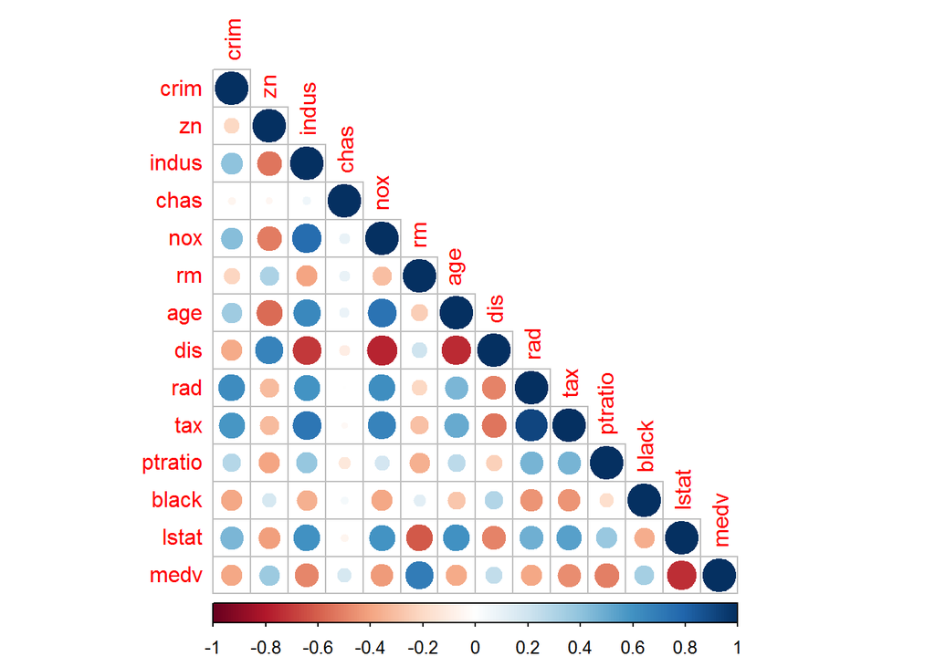

```r
library(corrplot)
corrplot(cr,type='lower')
```

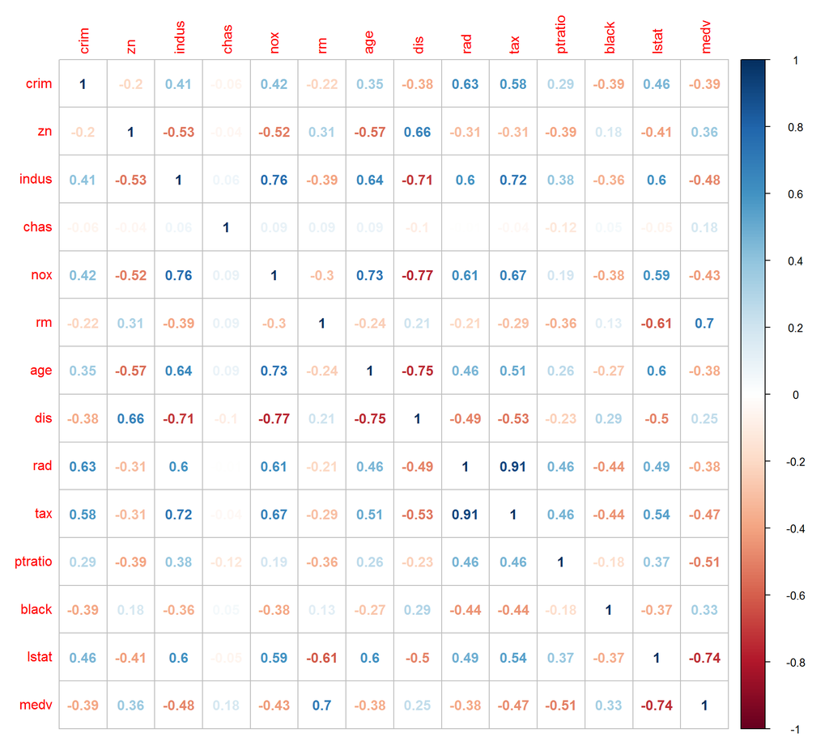

```r
corrplot(cr,method='number')
```

From figure values in dark blue is highly correlated and values in red is negatively correlated.

- medv and rm are +vely correlated.
- medv and lstat are negatively correlated.

### finding multicollinearity

```r
suppressMessages(library(caret))
# to exclude medv(output)
Boston_a = subset(Boston, select = -c(medv) )
numericData <- Boston_a[sapply(Boston_a, is.numeric)]
descrCor <- cor(numericData)
```

Using VIF(variance inflation factor) to detect multicollinearity

#### Implement model

. below means that all independant variables must be included.

```r
model <- lm(medv~., data = training_data)
vif(model)
```

```
##     crim       zn    indus     chas      nox       rm      age      dis
## 1.654454 2.300741 3.990279 1.072913 4.506525 1.820852 2.995407 3.897520
##      rad      tax  ptratio    black    lstat
## 7.120702 8.577992 1.997447 1.365848 2.641099
```

- **VIF** of 1 means there is no correlation among variables.
- If **vif** is very high => its highly correlated.
- nox, indux and dis are moderately correlated.
- Here, rad and tax have higher variance factor values indicating high muticollinearity.

To draw a corrgram

[figure not shown]

```r
suppressMessages(library(corrgram))
corrgram(cr)
```

```r
summary(model)
```

```
##
## Call:
## lm(formula = medv ~ ., data = training_data)
##
## Residuals:
##      Min       1Q   Median       3Q      Max
## -15.4036  -2.8472  -0.5166   1.8768  24.3219
##
## Coefficients:
##               Estimate Std. Error t value Pr(>|t|)
## (Intercept)  41.975065   6.171855   6.801 4.45e-11 ***
## crim         -0.124709   0.036198  -3.445 0.000639 ***
## zn            0.060213   0.016620   3.623 0.000334 ***
## indus         0.007313   0.073690   0.099 0.921005
## chas          2.366739   1.074791   2.202 0.028308 *
## nox         -21.354016   4.722318  -4.522 8.38e-06 ***
## rm            3.483738   0.487656   7.144 5.23e-12 ***
## age          -0.006623   0.015952  -0.415 0.678241
## dis          -1.859822   0.245499  -7.576 3.17e-13 ***
## rad           0.337442   0.076949   4.385 1.53e-05 ***
## tax          -0.012126   0.004312  -2.812 0.005201 **
## ptratio      -0.886151   0.164662  -5.382 1.35e-07 ***
## black         0.008751   0.003099   2.824 0.005009 **
## lstat        -0.590932   0.060140  -9.826  < 2e-16 ***
## ---
## Signif. codes:  0 '***' 0.001 '**' 0.01 '*' 0.05 '.' 0.1 ' ' 1
##
## Residual standard error: 4.914 on 353 degrees of freedom
## Multiple R-squared:  0.7408, Adjusted R-squared:  0.7312
## F-statistic:  77.6 on 13 and 353 DF,  p-value: < 2.2e-16
```

As per our summary the eqn representing our regression line is :

[output not shown]

#### Optimize model

```r
model <- lm(medv ~ crim + zn + chas + nox + rm + dis + ptratio + black + lstat, data = training_data)
summary(model)
```

```
##
## Call:
## lm(formula = medv ~ crim + zn + chas + nox + rm + dis + ptratio +
##     black + lstat, data = training_data)
##
## Residuals:
##      Min       1Q   Median       3Q      Max
## -15.4707  -2.9200  -0.7401   1.7857  25.8528
##
## Coefficients:
##               Estimate Std. Error t value Pr(>|t|)
## (Intercept)  32.944912   5.870572   5.612 4.02e-08 ***
## crim         -0.075267   0.034114  -2.206 0.027995 *
## zn            0.059915   0.016322   3.671 0.000279 ***
## chas          2.559408   1.088382   2.352 0.019237 *
## nox         -18.409747   4.002540  -4.600 5.89e-06 ***
## rm            3.819072   0.480013   7.956 2.37e-14 ***
## dis          -1.758164   0.234017  -7.513 4.69e-13 ***
## ptratio      -0.707358   0.146458  -4.830 2.03e-06 ***
## black         0.007488   0.003123   2.398 0.017012 *
## lstat        -0.605430   0.058708 -10.312  < 2e-16 ***
## ---
## Signif. codes:  0 '***' 0.001 '**' 0.01 '*' 0.05 '.' 0.1 ' ' 1
##
## Residual standard error: 5.031 on 357 degrees of freedom
## Multiple R-squared:  0.7253, Adjusted R-squared:  0.7184
## F-statistic: 104.7 on 9 and 357 DF,  p-value: < 2.2e-16
```

The Adjusted R-squared value remains almost same.

Now we can use our model to predict the output of our testing data.

We can use the following code for predicting the output.

```r
predic <- predict(model,testing_data)
predic
```

```
##         2         4         5         8         9        19        21
## 24.945246 28.525657 27.661958 17.771677  8.865734 17.373921 12.780148
##        23        24        26        27        31        34        35
## 16.196114 14.030047 13.950030 15.959476 11.491027 14.790007 14.280110
##        36        42        44        49        53        56        67
## 24.034256 27.778445 24.134827  6.633862 26.893428 30.702354 26.268430
##        72        74        80        87        90        94        97
## 22.058787 24.559074 23.639041 21.956118 31.894179 29.687226 25.471617
##       100       104       106       109       113       114       119
## 33.416336 22.053595 20.198301 24.556483 21.862296 21.678156 21.573830
##       123       130       131       132       133       134       135
## 19.803364 16.310325 22.704075 22.087417 22.816088 18.139355 15.736995
##       139       143       145       148       149       150       151
## 15.904793 13.866408  7.900072  7.632677  8.980103 14.647083 21.177684
##       164       167       170       171       173       174       178
## 42.936083 38.467070 27.314118 22.942125 22.596938 29.145735 29.248434
##       186       188       189       190       195       202       210
## 24.035101 34.983150 33.949393 35.957528 32.576562 30.806643 15.901039
##       223       224       226       228       230       235       236
## 31.245337 29.149214 39.608452 31.965114 30.985162 30.918643 24.334425
##       240       241       242       244       246       247       249
## 27.871439 26.352342 22.697682 26.820559 11.960850 19.332153 20.655386
##       252       255       256       268       270       271       273
## 25.034269 24.997476 22.507003 40.122627 25.384246 22.038810 28.794471
##       278       293       303       306       309       313       316
## 35.164499 33.038530 28.388021 30.094050 29.607575 23.786306 20.753226
##       320       321       330       334       340       344       346
## 21.448564 25.163446 25.900692 21.416966 20.642623 28.997938 16.898196
##       348       351       353       355       356       358       359
## 26.443293 22.183340 17.885629 15.578385 18.067055 21.665031 21.271697
##       364       371       374       376       380       382       385
## 19.315648 34.931065  4.115509 25.276921 16.049613 17.642759  2.004455
##       398       399       407       409       415       416       418
## 15.280558  5.669914  7.338408 12.375108 -4.929705  8.757397  6.388357
##       420       423       425       426       441       442       449
## 14.051511 18.231936 14.506549  9.413234 11.856636 16.207318 16.468088
##       453       459       471       473       477       487       494
## 17.459694 16.329576 18.979733 21.452340 19.353087 18.481469 21.889581
##       497       498       499       502       503       505
## 14.409630 20.050914 22.477063 25.438856 24.363695 28.302915
```

#### Model validation

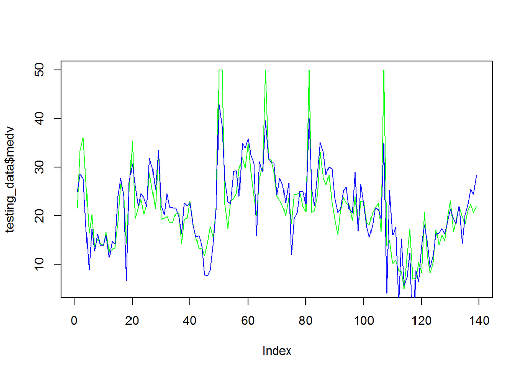

```r
plot(testing_data$medv, type = 'l',lty=1.8, col = 'green')
lines(predic, type = 'l',col = 'blue')
```

Now as the blue and green lines are very close this implies that the prediction is coming very nicely.

##### Now we can use this model to predict the output of sample dataset

```r
#predic <- predict(model, sample_data)
#predic
```